# Data624 Time Series Decomposition Assignment3

Ritesh Lohiya

February 22, 2019

# Data624 Time Series Decomposition Assignment3

# Chapter 6

# install.packages(“seasonal”)

```r
suppressMessages(suppressWarnings(library(fpp2)))
suppressMessages(suppressWarnings(library(forecast)))
suppressMessages(suppressWarnings(library(fma)))
suppressMessages(suppressWarnings(library(seasonal)))
```

#### 6.2 The plastics data set consists of the monthly sales (in thousands) of product A for a plastics manufacturer for five years. There is a positive trend throughout the series.

#### a. Plot the time series of sales of product A. Can you identify seasonal fluctuations and/or a trend-cycle?

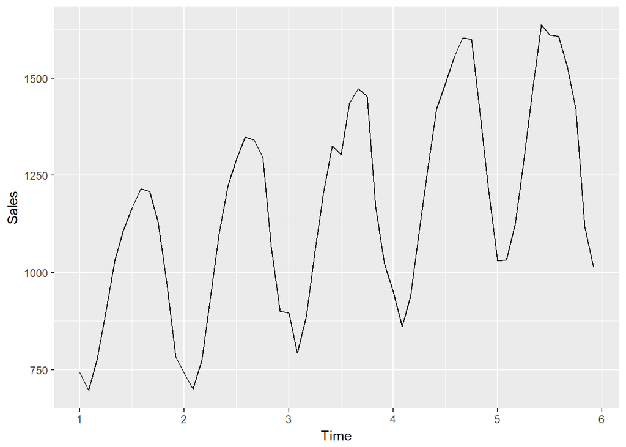

```r
autoplot(plastics)  +   xlab("Time") +   ylab("Sales")
```

#### Yes, we can see seasonal fluctuations where sales grow midway and drops at the beginning and end of the year. Also there is upward trend as the years increase.

#### b. Use a classical multiplicative decomposition to calculate the trend-cycle and seasonal indices.

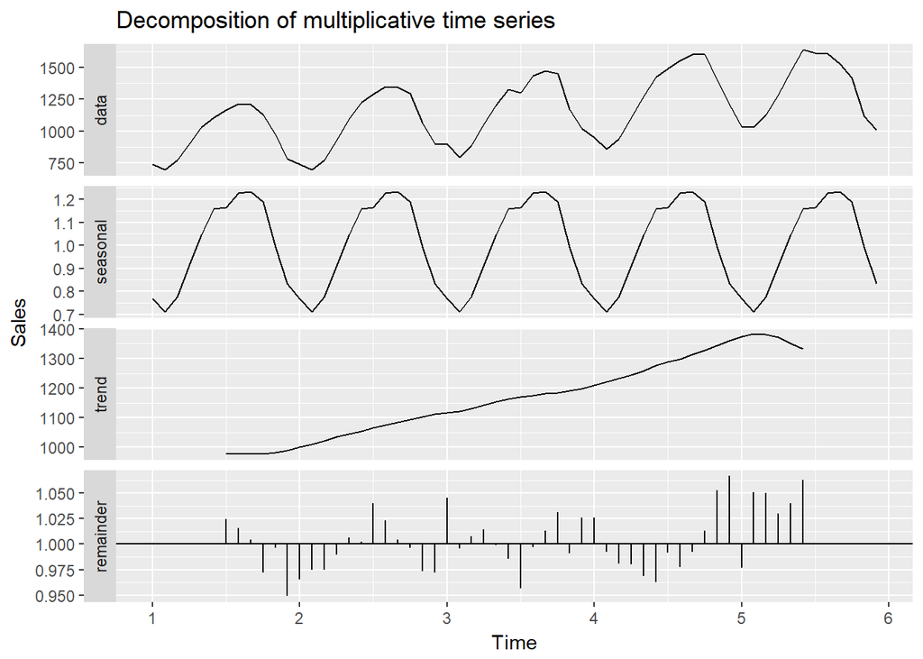

```r
decompose_plastics <- decompose(plastics, type = "multiplicative")
autoplot(decompose_plastics) +   xlab("Time") +   ylab("Sales")
```

#### c. Do the results support the graphical interpretation from part a?

#### Yes, the results support the graphical interpretation from part a.

#### d. Compute and plot the seasonally adjusted data.

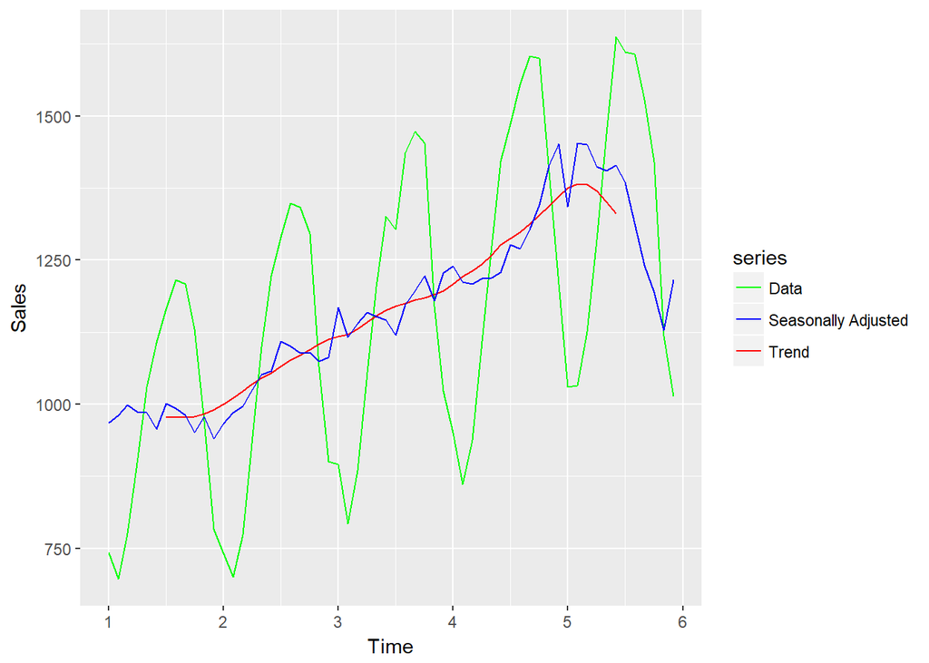

```r
autoplot(plastics, series="Data") +   autolayer(trendcycle(decompose_plastics), series="Trend") +
autolayer(seasadj(decompose_plastics), series="Seasonally Adjusted") + xlab("Time") + ylab("Sales") +
scale_colour_manual(values=c("green","blue","red"), breaks=c("Data","Seasonally Adjusted","Trend"))
```

#### e. Change one observation to be an outlier (e.g., add 500 to one observation), and recompute the seasonally adjusted data. What is the effect of the outlier?

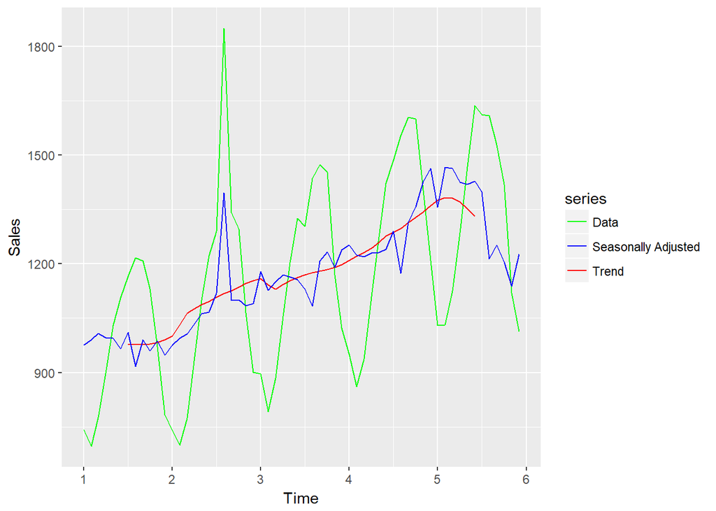

```r
plastics1 <- plastics
plastics1[20] <- plastics1[20] + 500
decompose_plastics1 <- decompose(plastics1,  type = "multiplicative")
autoplot(plastics1, series = "Data") + autolayer(trendcycle(decompose_plastics1), series = "Trend") + autolayer(seasadj(decompose_plastics1),
series = "Seasonally Adjusted") + xlab("Time") + ylab("Sales") +
scale_color_manual(values=c("green", "blue", "red"), breaks=c("Data", "Seasonally Adjusted", "Trend"))
```

#### Outliers affects the seasonally adjusted data severely.

#### f. Does it make any difference if the outlier is near the end rather than in the middle of the time series?

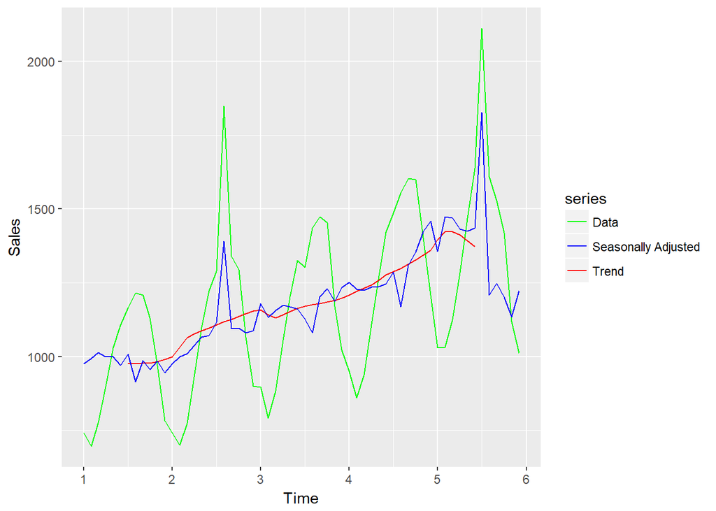

```r
plastics1[55] <- plastics1[55] + 500
decompose_plastics1 <- decompose(plastics1, type = "multiplicative")

autoplot(plastics1, series = "Data") + autolayer(trendcycle(decompose_plastics1), series = "Trend") + autolayer(seasadj(decompose_plastics1),
series = "Seasonally Adjusted") + xlab("Time") + ylab("Sales") + scale_color_manual(values=c("green", "blue", "red"), breaks=c("Data", "Seasonally Adjusted", "Trend"))
```

#### If an outlier is near the end, the effect to trend decreases.

#### 6.3 Recall your retail time series data (from Exercise 3 in Section 2.10). Decompose the series using X11. Does it reveal any outliers, or unusual features that you had not noticed previously?

Retails data:

```r
retaildata <- readxl::read_excel("C:/Users/rites/Documents/GitHub/Data624_Assignment1/retail.xlsx", skip=1)
```

```
## readxl works best with a newer version of the tibble package.
## You currently have tibble v1.4.2.
## Falling back to column name repair from tibble <= v1.4.2.
## Message displays once per session.
```

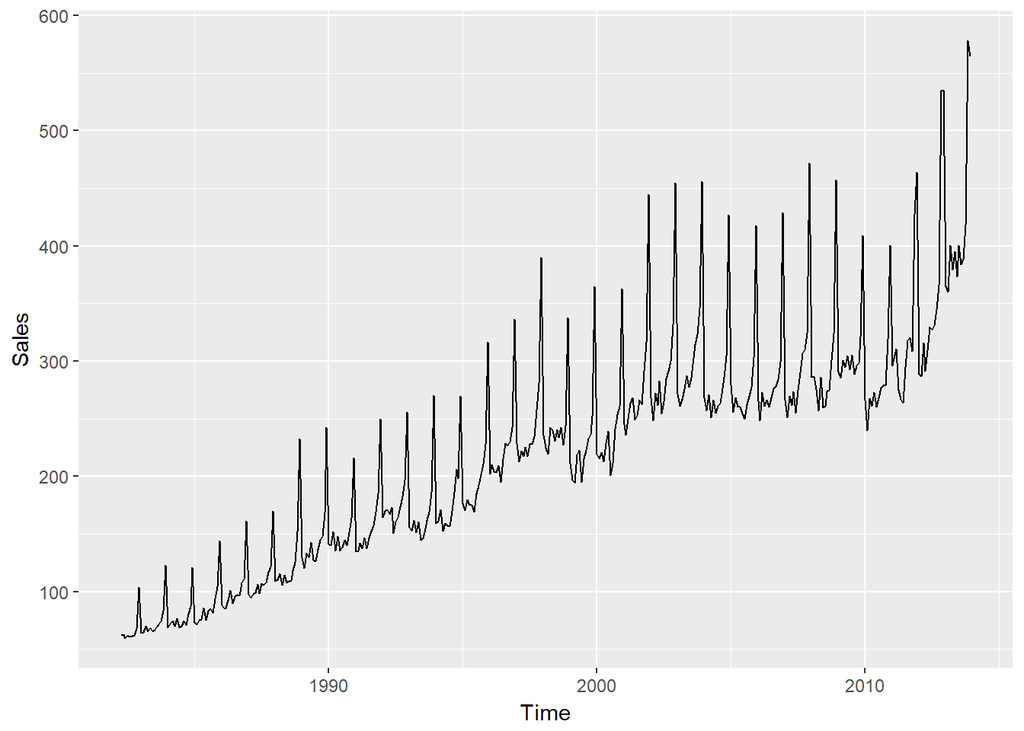

```r
myts <- ts(retaildata[,"A3349873A"],frequency=12, start=c(1982,4))
autoplot(myts) + xlab("Time") + ylab("Sales")
```

#### There are trend and seasonality.

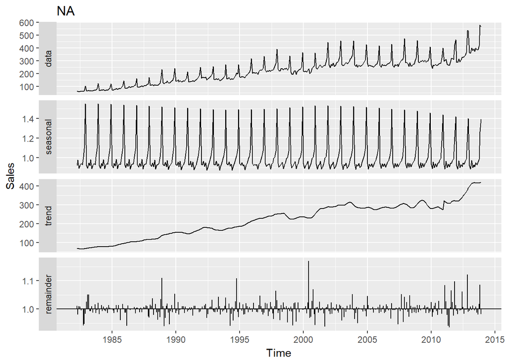

```r
# Decompose the series using X11.
retail_x11<- seas(myts, x11 = "")
autoplot(retail_x11) + xlab("Time") + ylab("Sales")
```